# Phenotype and Genomics data analysis using the TCGA dataset

SID: 500341067

2022-04-16

# 1 Summary

In this report we will look at the TCGA dataset which is a cancer genomics dataset widely used in omics analysis. After some data cleaning on the phenotype data, we will perform PCA to see if we can split patient into different cluster according to the stage of their tumor. We will then perform Differential Expression Analysis to see what genes are up and down regulated in patient with tumor. Finally, we will use these results for Pathway analysis by focusing on two important pathways.

# 2 Principal component analysis on phenotype data

## 2.1 Data Preprocessing

To perform PCA we can only use numeric variable, however some important columns are of type “character”. We will convert the gender and cancer stage variables to numeric :

```r
sample = samples %>%
  mutate(gdc_cases.demographic.gender = case_when(gdc_cases.demographic.gender == "male" ~ as.integer(0), gdc_cases.demographic.gender == "female" ~ as.integer(1))) %>%
  filter(gdc_cases.diagnoses.tumor_stage != "not reported") %>%
  mutate(
         gdc_cases.diagnoses.tumor_stage = case_when(
           str_detect(gdc_cases.diagnoses.tumor_stage, "iv") ~ as.integer(4),
           str_detect(gdc_cases.diagnoses.tumor_stage,"iii") ~ as.integer(3),
           str_detect(gdc_cases.diagnoses.tumor_stage, "ii") ~ as.integer(2),
           str_detect(gdc_cases.diagnoses.tumor_stage, "i") ~ as.integer(1),
           gdc_cases.diagnoses.tumor_stage == "stage 0" ~as.integer(0)

         ))
```

## 2.2 Data Cleaning

The TCGA phenotype dataset contains many columns and some of those have NAs for all patients. We therefore start by deleting all those columns.

```r
# deleting columns with only NAs
sample = sample %>%
  dplyr::select(where(~!all(is.na(.x))))
```

We now create a new data frame num_df containing only numeric variable as we want to perform a PCA. We then use the vis_miss function fron the vis_dat package to visualize the proportion of NAs in each column.

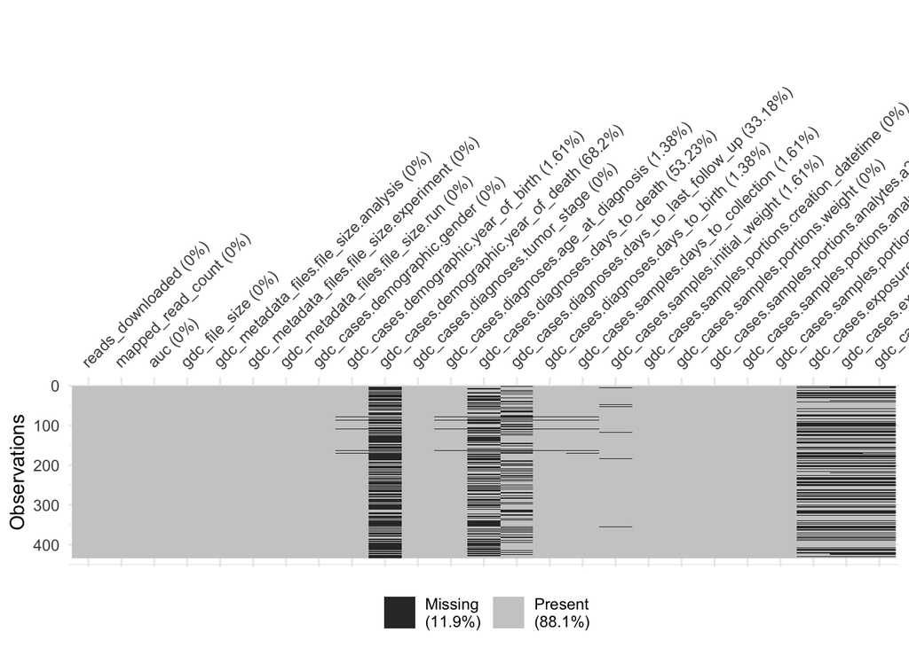

```r
num_df= sample %>%
  dplyr::select(where(is.numeric))

# Let's visualise the missing data in the numeric dataframe
num_df %>%
  dplyr::select(c(1:25)) %>%
  visdat::vis_miss()
```

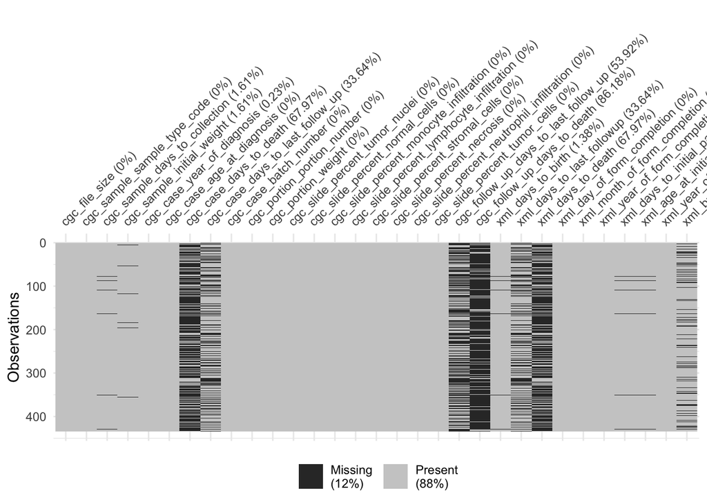

```r
num_df %>%
  dplyr::select(c(26:56)) %>%
  visdat::vis_miss()
```

We can see that some data cleaning is still needed. Indeed we need to have no missing values to perform PCA. We can not have the same approach for all columns when treating NAs.

Here, it is clear that some values are Missing Not At Random. It is the case for columns relating to “death”. If there are missing values in this column, it might be safe to assume that the patient is not dead so variable such as year of death for these patients are meaningless

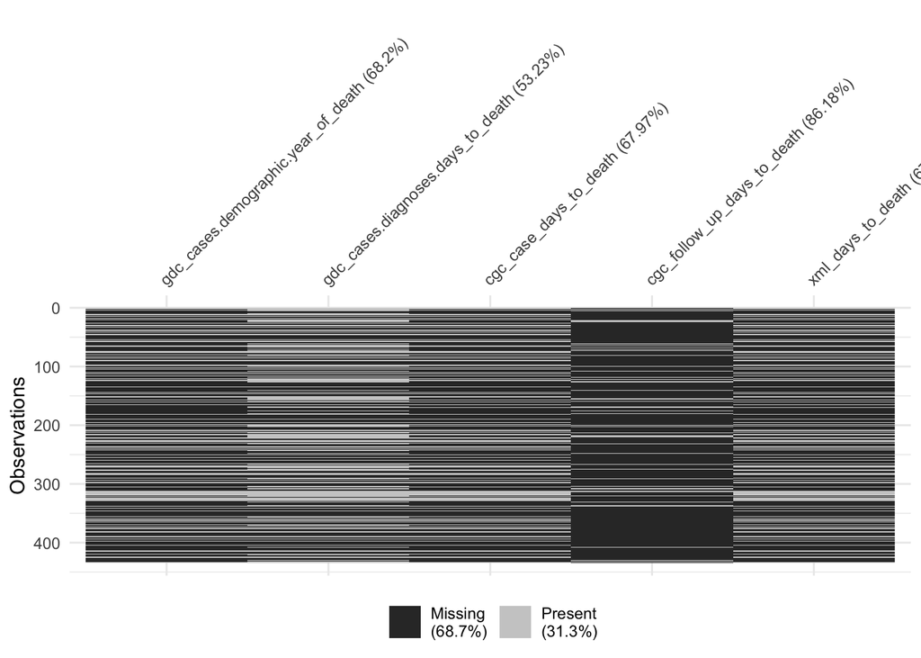

```r
death_df = num_df %>%
  dplyr::select(contains("death"))

visdat::vis_miss(death_df)
```

```r
death_df %>% summary()
```

```
##  gdc_cases.demographic.year_of_death gdc_cases.diagnoses.days_to_death
##  Min.   :1995                        Min.   :   79.0
##  1st Qu.:2005                        1st Qu.:  511.5
##  Median :2007                        Median : 1026.0
##  Mean   :2007                        Mean   : 1692.7
##  3rd Qu.:2009                        3rd Qu.: 2025.0
##  Max.   :2014                        Max.   :10870.0
##  NA's   :296                         NA's   :231
##  cgc_case_days_to_death cgc_follow_up_days_to_death xml_days_to_death
##  Min.   :   79.0        Min.   :  190.0             Min.   :   79.0
##  1st Qu.:  557.5        1st Qu.:  368.8             1st Qu.:  557.5
##  Median : 1026.0        Median :  984.0             Median : 1026.0
##  Mean   : 1747.8        Mean   : 1515.2             Mean   : 1747.8
##  3rd Qu.: 2050.5        3rd Qu.: 2009.2             3rd Qu.: 2050.5
##  Max.   :10870.0        Max.   :10346.0             Max.   :10870.0
##  NA's   :295            NA's   :374                 NA's   :295
```

We assume that when the year of death is missing, the individual is a cancer survivor. We also assume that the life expectancy of a cancer survivor is the same as an individual which might not have cancer. Therefore, if the year of death is missing, we will make it equal to the year of birth + 79 as 79 is the life expectancy in the USA as of 2019. For most of the patients we now have the year of birth, the year of death and the age when diagnosed with cancer. Therefore, we can compute the values for each “Death column”. We can see that the number of missing values has greatly been reduced. .

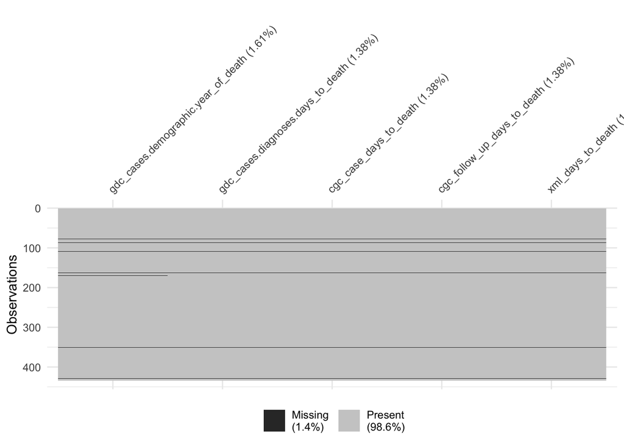

```r
num_df = num_df %>%
  mutate(
    gdc_cases.demographic.year_of_death =
      case_when(
        is.na(gdc_cases.demographic.year_of_death) ~ as.integer(round(gdc_cases.demographic.year_of_birth + 79)),
        TRUE ~ gdc_cases.demographic.year_of_death)
    )

num_df = num_df %>%
  mutate(
    gdc_cases.diagnoses.days_to_death =
     case_when(
    is.na(gdc_cases.diagnoses.days_to_death) ~ as.numeric(round(365*(gdc_cases.demographic.year_of_death - (gdc_cases.demographic.year_of_birth + gdc_cases.diagnoses.age_at_diagnosis)))),
       TRUE ~ gdc_cases.diagnoses.days_to_death
      ),
    cgc_case_days_to_death = case_when(
      is.na(cgc_case_days_to_death) ~as.integer(round(365*(gdc_cases.demographic.year_of_death - cgc_case_year_of_diagnosis))),
         TRUE ~ cgc_case_days_to_death
      ),
    cgc_follow_up_days_to_death =case_when(
      is.na(cgc_follow_up_days_to_death) ~ cgc_case_days_to_death, TRUE ~ cgc_follow_up_days_to_death
      ),
    xml_days_to_death = case_when(
      is.na(xml_days_to_death) ~ cgc_case_days_to_death, TRUE ~ xml_days_to_death
      )
    )

death_df2 = num_df %>%
  dplyr::select(contains("death"))
visdat::vis_miss(death_df2)
```

There are still columns with missing values. We will delete all columns with more than 30% of NAs and then omit all rows with NAs:

```r
dim(num_df)[1] -round(473 * 0.3)
```

```
## [1] 292
```

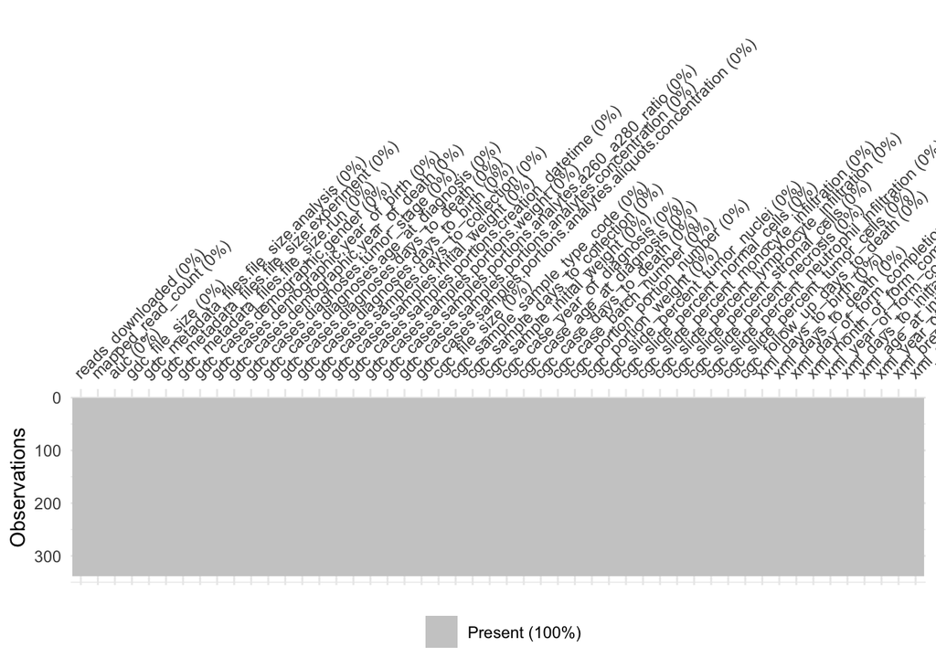

```r
num_df = num_df %>%
  dplyr::select(where(~sum(!is.na(.x)) > 331)) %>%
  na.omit()
visdat::vis_miss(num_df)
```

```r
dim(num_df)
```

```
## [1] 338  50
```

Finally, we obtain a dataframe of 338 rows and 50 columns with no missing data. We are now ready to perform a PCA

## 2.3 Performing PCA

To perform PCA, we need a matrix with numeric vectors with no zero variance. Thus we delete the column xml_days_to_initial_pathologic_diagnosis as it containz 0 for all rows. We then can scale the data to perform PCA:

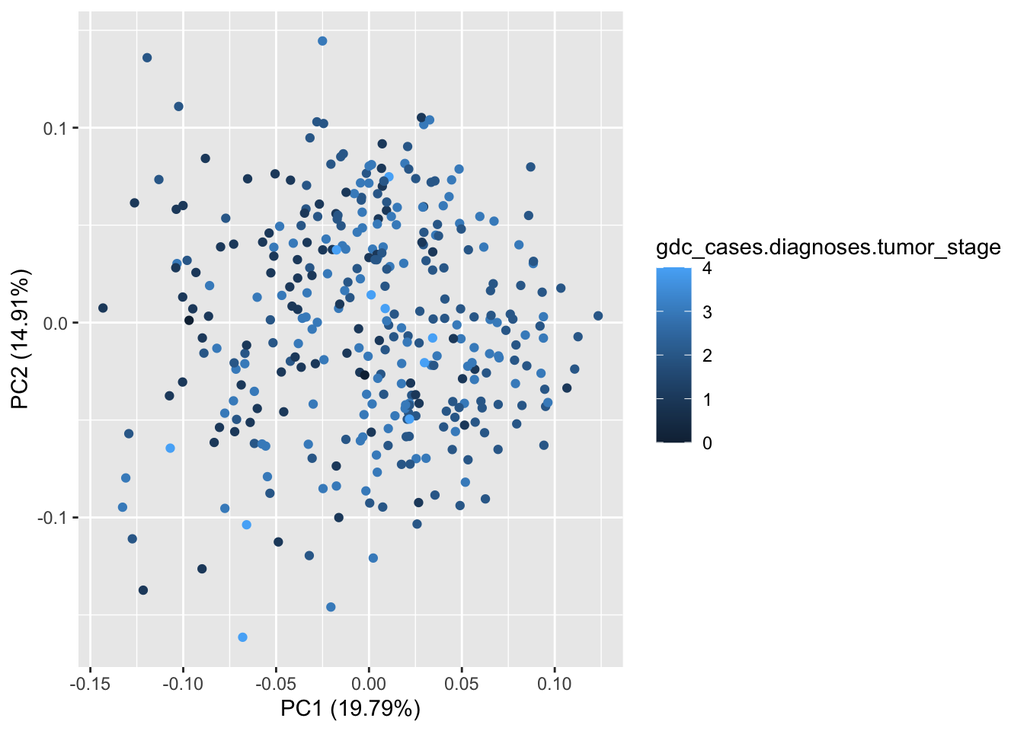

```r
scale_df = num_df %>%
  dplyr:: select(-xml_days_to_initial_pathologic_diagnosis) %>%
  scale()

pca = prcomp(scale_df, scale. = FALSE)
autoplot(pca, data = num_df, colour = "gdc_cases.diagnoses.tumor_stage")
```

Unfortunately, no clear trend can be seen on this plot. It seems that the stage of the tumor cannot easily be explained by phenotype data. Thus, we will start to explore the genomics data and see if we can obtain any meaningful result.

# 3 Differential Expression Analysis

In this part of the report, we will perform Differential Expression Analysis (DEA) on the TCGA dataset. In particular we will be interested in determining which genes are up regulated and down-regulated when comparing patient with tumor to patient without tumor. The number of patient in each category can be observed in the table below:

```r
DEA_dat = sample %>%
  filter(cgc_case_tumor_status != "NA")

DEA_dat %>% group_by(cgc_case_tumor_status) %>% summarize(n = n())
```

| cgc_case_tumor_status | n |
| --- | --- |
| TUMOR FREE | 208 |
| WITH TUMOR | 203 |

First, we need to create a new RandomSummarizedExperiment object which contains all the data of every patient except those where the status of the tumor is missing. We can then create a DGEList that contain all the data needed to perform DEA.

```r
list1<- which(!samples$cgc_case_tumor_status == ("NA")) #This makes a list of the samples
TCGA <- rse_gene[,list1] #make a new DGE list just containing the samples that have tumor
dim(TCGA)
```

```
## [1] 58037   445
```

```r
counts_T <- assay(TCGA)
genes_T <- rowData(TCGA)
samples_T <- as.data.frame(colData(TCGA))

Exp_list_TCGA = DGEList(counts = counts_T, samples = samples_T, genes = genes_T)
```

We then use the limma package to perform gene expression to compare patient with and without tumors.

```r
design_T = model.matrix(~cgc_case_tumor_status, data = Exp_list_TCGA$samples)
head(design_T)
```

```
##                                      (Intercept)
## 72189C87-53DD-427E-B163-91E404577A7A           1
## 27496AAB-AC06-4100-BB41-0029F63CC678           1
## 3BBC7540-136B-47C8-9C09-CD423685B742           1
## 1B2EC3E0-16A7-4F82-A123-B85A2CE01E63           1
## 82DA87CF-C067-44B3-A372-ECB056337B08           1
## 8A35116A-7F2B-49F8-A497-398959BB1AD9           1
##                                      cgc_case_tumor_statusWITH TUMOR
## 72189C87-53DD-427E-B163-91E404577A7A                               1
## 27496AAB-AC06-4100-BB41-0029F63CC678                               1
## 3BBC7540-136B-47C8-9C09-CD423685B742                               1
## 1B2EC3E0-16A7-4F82-A123-B85A2CE01E63                               1
## 82DA87CF-C067-44B3-A372-ECB056337B08                               1
## 8A35116A-7F2B-49F8-A497-398959BB1AD9                               1
```

We use the voom function to generate an EList object which will be need for the next modelling steps.

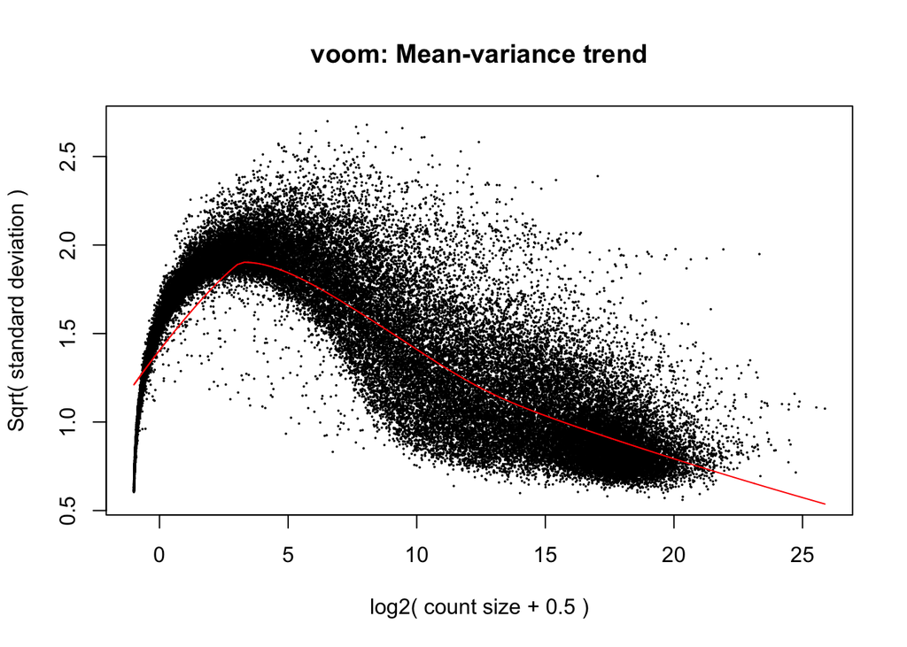

```r
v_plot = voom(Exp_list_TCGA, design_T, plot = TRUE)
```

We now perform a linear model using v_plot, the linear model is then used to fit an emperical Bayes moderation to get a better estimates of gene-wise variability

```r
fit = lmFit(v_plot, design_T)
fit2 = eBayes(fit)
```

Finally, we use the the fitted model obtained with the eBayes() function to determine the number of up and down regulated genes.

```r
results = decideTests(fit2, adjust.method = "fdr", p.value = 0.05)
results %>% summary()
```

```
##        (Intercept) cgc_case_tumor_statusWITH TUMOR
## Down         39777                             769
## NotSig         802                           56927
## Up           17458                             341
```

# 4 Pathway Analysis

As a last part of our report, we will perform Pathway Analysis on the genes of patients present in the TCGA dataset. We will focus on down regulated genes as they seems to be more present than up-regulated gene in patients with tumor.

First, we collect the genes expressed in the TCGA dataset and we match these gene sets to the genes in our expression data stored in the voom object.

```r
load(url("http://bioinf.wehi.edu.au/software/MSigDB/human_c2_v5p2.rdata"))
idx_TCGA <- ids2indices(Hs.c2$TCGA, id = v_plot$genes$symbol)
```

Now, we can use the camera function from the limma package to test which set of genes are highly ranked relative to other genes in terms of differential expression when looking at patients with tumor. We then use the filter function from dplyr to only select genes that are down regulated. The name of the pathway as well as different information such as the number of genes and the p-value can be seen in the table below:

```r
cam.TCGA <- camera(v_plot, idx_TCGA, design_T, contrast = "cgc_case_tumor_statusWITH TUMOR")
cam.TCGA$pathway = row.names(cam.TCGA)
downCam_TCGA = cam.TCGA %>% dplyr::filter(Direction == "Down")
head(downCam_TCGA)
```

|  | NGenes | Direction | PValue | FDR | pathway |
| --- | --- | --- | --- | --- | --- |
| AMUNDSON_DNA_DAMAGE_RESPONSE_TP53 | 15 | Down | 0.001378304 | 0.4306409 | AMUNDSON_DNA_DAMAGE_RESPONSE_TP53 |
| DER_IFN_GAMMA_RESPONSE_DN | 10 | Down | 0.001508833 | 0.4306409 | DER_IFN_GAMMA_RESPONSE_DN |
| DAVICIONI_RHABDOMYOSARCOMA_PAX_FOXO1_FUSION_UP | 42 | Down | 0.002732079 | 0.4468594 | DAVICIONI_RHABDOMYOSARCOMA_PAX_FOXO1_FUSION_UP |
| REACTOME_ADHERENS_JUNCTIONS_INTERACTIONS | 10 | Down | 0.003225049 | 0.4468594 | REACTOME_ADHERENS_JUNCTIONS_INTERACTIONS |
| VARELA_ZMPSTE24_TARGETS_UP | 35 | Down | 0.007385447 | 0.5647171 | VARELA_ZMPSTE24_TARGETS_UP |
| SA_TRKA_RECEPTOR | 14 | Down | 0.007539081 | 0.5647171 | SA_TRKA_RECEPTOR |

We can use the filter function again to check if any pathways have more than 200 genes:

```r
Max_down_cam_TCGA = downCam_TCGA %>% filter (NGenes > 200)
Max_down_cam_TCGA
```

|  | NGenes | Direction | PValue | FDR | pathway |
| --- | --- | --- | --- | --- | --- |
| AGUIRRE_PANCREATIC_CANCER_COPY_NUMBER_UP | 247 | Down | 0.7231614 | 0.9447771 | AGUIRRE_PANCREATIC_CANCER_COPY_NUMBER_UP |
| DEBIASI_APOPTOSIS_BY_REOVIRUS_INFECTION_DN | 240 | Down | 0.8528178 | 0.9740305 | DEBIASI_APOPTOSIS_BY_REOVIRUS_INFECTION_DN |
| GRAESSMANN_APOPTOSIS_BY_SERUM_DEPRIVATION_UP | 386 | Down | 0.8688655 | 0.9793091 | GRAESSMANN_APOPTOSIS_BY_SERUM_DEPRIVATION_UP |

We can focus on the GRAESSMANN_APOPTOSIS_BY_SERUM_DEPRIVATION_UP as it is the pathway with the highest number of Genes. A barcode plot for this pathway and using our gene expression data sorted by differential expression can be seen below:

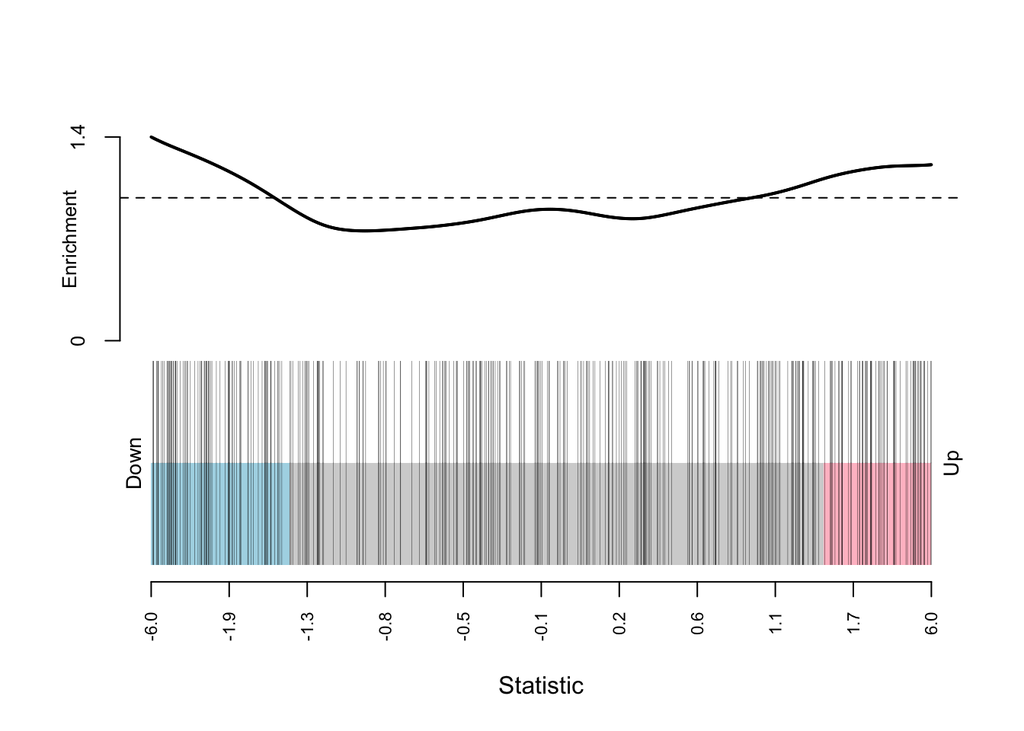

```r
barcodeplot(fit2$t[,"cgc_case_tumor_statusWITH TUMOR"], index = idx_TCGA$GRAESSMANN_APOPTOSIS_BY_SERUM_DEPRIVATION_UP)
```

However, the PValue for the last pathway is not significant. Let’s focus on a different pathway. Again, we use the filter function to find a pathway with a p-value lower than 0.002 in patients with tumor:

```r
Sign_pathway = downCam_TCGA %>% filter(PValue < 0.002)
Sign_pathway
```

|  | NGenes | Direction | PValue | FDR | pathway |
| --- | --- | --- | --- | --- | --- |
| AMUNDSON_DNA_DAMAGE_RESPONSE_TP53 | 15 | Down | 0.001378304 | 0.4306409 | AMUNDSON_DNA_DAMAGE_RESPONSE_TP53 |
| DER_IFN_GAMMA_RESPONSE_DN | 10 | Down | 0.001508833 | 0.4306409 | DER_IFN_GAMMA_RESPONSE_DN |

We will use the AMUNDSON_DNA_DAMAGE_RESPONSE_TP53 pathway as it has the lowest Pvalue. As before, the barcode plot can be seen below:

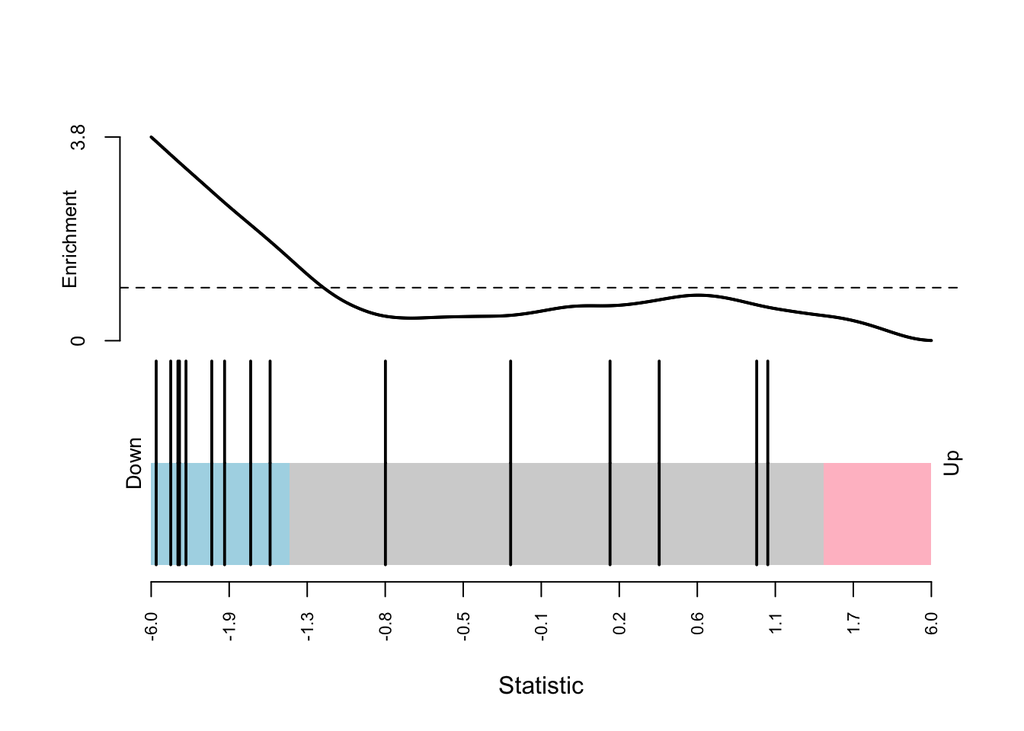

```r
barcodeplot(fit2$t[,"cgc_case_tumor_statusWITH TUMOR"], index = idx_TCGA$AMUNDSON_DNA_DAMAGE_RESPONSE_TP53)
```

We can see that non of the genes in the AMUNDSON_DNA_DAMAGE_RESPONSE_TP53 pathway are up regulated. Furthermore, the highest enrichment value occur in down regulated genes.